# DATS 6101 Team 1 - Project 1

# Introduction

Our research topic aims to perform explorartory data analysis on the Nearest Earth Objects (NEO) dataset recorded by NASA. This particular dataset includes thousands of labeled observations, over the last 22 years, across multiple attributes that each aim to describe a specific object. Borrowing from the humor of the recent film *Don’t Look Up* by Adam Mckay and NASA’s success in the Double Asteroid Redirection Test (DART) mission, we thought that further describing and exploring this dataset would be opportune.

The EDA performed can help with the early detection of an asteroid. With the early detection, NASA can take quick remedies to help eliminate the threat. NASA’s DART mission (Double Asteroid Redirection Test) was done for the same purpose. It was designed to deflect an asteroid with a certain momentum by hitting it head-on or attempting to slow it down. More can be read online from this [article](https://en.wikipedia.org/wiki/Double_Asteroid_Redirection_Test).

According to NASA’s [official documentation](https://cneos.jpl.nasa.gov/about/neo_groups.html), a PHA is technically termed using parameters that measure the asteroid’s characteristics and then make a decision if the asteroid is considered hazardous based on certain thresholds. Specifically, all asteroids with an Earth Minimum Orbit intersection Distance (MOID) of 0.05 au or less and an absolute magnitude (H) of 22.0 or less are considered Potentially Hazardous Asteroids (PHAs). In other words, asteroids that can’t get any closer to the Earth (i.e., MOID) than 0.05 au (roughly 7,480,000km) or are smaller than about 140m in diameter (i.e., H=22.0) are not considered PHAs.

The current dataset that we have contains 90,000 rows. Each row represents a NEO identified by an ID and name. Out of these 90,000 rows, 9,000 of them are hazardous and 81,000 of them are non-hazardous. This dataset does not contain null values. Apart from the hazardous target variable, our dataset contains 5 numerical variables that can help identify if the asteroid is hazardous or not. These 5 variables are:

1. est_diameter_min (km) – estimated minimum diameter of the NEO
2. est_diameter_max (km) – estimated maximum diameter of the NEO
3. relative_velocity – the velocity (in km/seconds) with which the NEO was travelling with respect to Earth
4. miss_distance – distance (in km) by which the asteroid missed the Earth’s surface
5. absolute_magnitude (H) – signifies the brightness of the asteroid

Out of these 5 variables, we have 3 variables that play a primary role in determining if the asteroid was harmful or not. Those are:

1. relative_velocity
2. miss_distance
3. absolute_magnitude

Throughout the rest of this RMD file, we will try to build a binary classification model that would use these parameters and then predict if any future asteroid that is striking the Earth would be hazardous or not?

# Let’s explore the dataset

Displaying the structure of the data:

```
## 'data.frame':    90836 obs. of  10 variables:
##  $ id                : int  2162635 2277475 2512244 3596030 3667127 54138696 54189957 54230078 2088213 3766065 ...
##  $ name              : chr  "162635 (2000 SS164)" "277475 (2005 WK4)" "512244 (2015 YE18)" "(2012 BV13)" ...
##  $ est_diameter_min  : num  1.1983 0.2658 0.722 0.0965 0.255 ...
##  $ est_diameter_max  : num  2.679 0.594 1.615 0.216 0.57 ...
##  $ relative_velocity : num  13569 73589 114259 24764 42738 ...
##  $ miss_distance     : num  54839744 61438127 49798725 25434973 46275567 ...
##  $ orbiting_body     : chr  "Earth" "Earth" "Earth" "Earth" ...
##  $ sentry_object     : chr  "False" "False" "False" "False" ...
##  $ absolute_magnitude: num  16.7 20 17.8 22.2 20.1 ...
##  $ hazardous         : chr  "False" "True" "False" "False" ...
## NULL
```

Displaying the first 6 rows of the dataset:

```
##         id                name est_diameter_min est_diameter_max
## 1  2162635 162635 (2000 SS164)           1.1983           2.6794
## 2  2277475   277475 (2005 WK4)           0.2658           0.5943
## 3  2512244  512244 (2015 YE18)           0.7220           1.6145
## 4  3596030         (2012 BV13)           0.0965           0.2158
## 5  3667127         (2014 GE35)           0.2550           0.5702
## 6 54138696         (2021 GY23)           0.0364           0.0813
##   relative_velocity miss_distance orbiting_body sentry_object
## 1             13569      54839744         Earth         False
## 2             73589      61438127         Earth         False
## 3            114259      49798725         Earth         False
## 4             24764      25434973         Earth         False
## 5             42738      46275567         Earth         False
## 6             34298      40585691         Earth         False
##   absolute_magnitude hazardous
## 1               16.7     False
## 2               20.0      True
## 3               17.8     False
## 4               22.2     False
## 5               20.1      True
## 6               24.3     False
```

The number of NA values in the dataset => 0

Now, we split the dataset into 2 dataframes - one for hazardous and other for non-hazardous. This is to ease out the tests performed.

The dimensions of hazardous asteroids dataframe: 8840, 10

The dimensions of non_hazardous asteroids dataframe: 81996, 10

# Performing measures of central tendency using Summary

Summary of all asteroids is as follows:

```
##        id               name           est_diameter_min est_diameter_max
##  Min.   : 2000433   Length:90836       Min.   : 0.0     Min.   : 0.0
##  1st Qu.: 3448110   Class :character   1st Qu.: 0.0     1st Qu.: 0.0
##  Median : 3748362   Mode  :character   Median : 0.0     Median : 0.1
##  Mean   :14382878                      Mean   : 0.1     Mean   : 0.3
##  3rd Qu.: 3884023                      3rd Qu.: 0.1     3rd Qu.: 0.3
##  Max.   :54275914                      Max.   :37.9     Max.   :84.7
##  relative_velocity miss_distance      orbiting_body      sentry_object
##  Min.   :   203    Min.   :    6746   Length:90836       Length:90836
##  1st Qu.: 28619    1st Qu.:17210820   Class :character   Class :character
##  Median : 44190    Median :37846579   Mode  :character   Mode  :character
##  Mean   : 48067    Mean   :37066546
##  3rd Qu.: 62924    3rd Qu.:56548996
##  Max.   :236990    Max.   :74798651
##  absolute_magnitude  hazardous
##  Min.   : 9.2       Length:90836
##  1st Qu.:21.3       Class :character
##  Median :23.7       Mode  :character
##  Mean   :23.5
##  3rd Qu.:25.7
##  Max.   :33.2
```

# PROJECT 2

Before we begin any modeling, it is good practice to perform some feature engineering.

# Sampling of data

## Helper functions

```r
Standardization <- function(data) {
  return (scale(data[,1:3], center = TRUE, scale = TRUE))
}

basicKNN5 <- function() {
  knn.5 <- knn(train=nasa_train, test=nasa_test, cl=nasa_train.labels, k=5)
  print(100 * sum(nasa_test.labels == knn.5)/NROW(nasa_test.labels))
  confusionMatrix(knn.5, as.factor(nasa_test.labels), mode="everything")
}
```

As part of feature engineering, let’s first consider a base model to play with. The base model that we are considering here is the KNN model with a k=5. Below is the R code of performing the split without any sampling technique used. We would also be using the training and testing data to check the accuracy of a base KNN model. We would implement this KNN model with the k value equal to 5 for the purpose of comparison between different sampling techniques.

## No sampling technique used:

```r
#str(neo)
set.seed(123)

neo_no_sampling = (neo %>% select(relative_velocity, absolute_magnitude, miss_distance, hazardous))
smp_size <- floor(0.75 * nrow(neo_no_sampling))
train_data_size <- sample(seq_len(nrow(neo_no_sampling)), size = smp_size)


nasa_train.labels = neo_no_sampling[train_data_size,c("hazardous")]
nasa_test.labels = neo_no_sampling[-train_data_size,c("hazardous")]

neo_no_sampling = neo_no_sampling %>% select(relative_velocity, miss_distance, absolute_magnitude)
nasa_train <- neo_no_sampling[train_data_size,]
nasa_test <- neo_no_sampling[-train_data_size,]

# Standardization
nasa_train = Standardization(nasa_train)
nasa_test = Standardization(nasa_test)

basicKNN5()
```

```
## [1] 89.9
```

```
## Confusion Matrix and Statistics
##
##           Reference
## Prediction False  True
##      False 19747  1531
##      True    764   667
##
##                Accuracy : 0.899
##                  95% CI : (0.895, 0.903)
##     No Information Rate : 0.903
##     P-Value [Acc > NIR] : 0.985
##
##                   Kappa : 0.315
##
##  Mcnemar's Test P-Value : <2e-16
##
##             Sensitivity : 0.963
##             Specificity : 0.303
##          Pos Pred Value : 0.928
##          Neg Pred Value : 0.466
##               Precision : 0.928
##                  Recall : 0.963
##                      F1 : 0.945
##              Prevalence : 0.903
##          Detection Rate : 0.870
##    Detection Prevalence : 0.937
##       Balanced Accuracy : 0.633
##
##        'Positive' Class : False
##
```

The next sampling technique we can use is called downsampling. This ensures that the data that we choose has equal proportions of hazardous and non-hazardous asteroids. For the purpose of implementing downsampling, we will retain all the rows in hazardous and randomly sample equal number of rows from non-hazardous. In other words, we would be bringing down the number of rows in non-hazardous from ~80,000 to ~8,000 rows.

## Downsampling

```r
set.seed(123)
non_hazardous = non_hazardous[sample(nrow(non_hazardous),nrow(hazardous)),]
neo_downsampling= rbind(hazardous, non_hazardous)
nrow(neo_downsampling)
```

```
## [1] 17680
```

```r
## 75% of the sample size
smp_size <- floor(0.75 * nrow(neo_downsampling))

## set the seed to make your partition reproducible
set.seed(123)
train_data_size <- sample(seq_len(nrow(neo_downsampling)), size = smp_size)

nasa_train.labels = neo_downsampling[train_data_size,c("hazardous")]
nasa_test.labels = neo_downsampling[-train_data_size,c("hazardous")]

neo_downsampling = neo_downsampling %>% select(relative_velocity, miss_distance, absolute_magnitude)
nasa_train <- neo_downsampling[train_data_size,]
nasa_test <- neo_downsampling[-train_data_size,]

# Standardization
nasa_train = Standardization(nasa_train)
nasa_test = Standardization(nasa_test)

basicKNN5()
```

```
## [1] 85.4
```

```
## Confusion Matrix and Statistics
##
##           Reference
## Prediction False True
##      False  1696  159
##      True    486 2079
##
##                Accuracy : 0.854
##                  95% CI : (0.843, 0.864)
##     No Information Rate : 0.506
##     P-Value [Acc > NIR] : <2e-16
##
##                   Kappa : 0.708
##
##  Mcnemar's Test P-Value : <2e-16
##
##             Sensitivity : 0.777
##             Specificity : 0.929
##          Pos Pred Value : 0.914
##          Neg Pred Value : 0.811
##               Precision : 0.914
##                  Recall : 0.777
##                      F1 : 0.840
##              Prevalence : 0.494
##          Detection Rate : 0.384
##    Detection Prevalence : 0.420
##       Balanced Accuracy : 0.853
##
##        'Positive' Class : False
##
```

From downsampling result above, we see that the results have become more realistic. In other words, we see that our Specificity rate has increased to 92% which is a great indicator of a great model. However, one biggest disadvantage of downsampling is loss of data. We are training the model with insufficient amount of data.

The next obvious sampling technique is upsampling. One such case of upsampling is SMOTE. Smote created artificial data points to bring up the data points in minority class.

## SMOTE

```r
set.seed(123)

neo_smote = (neo %>% select(relative_velocity, absolute_magnitude, miss_distance, hazardous))
neo_smote$hazardous[neo_smote$hazardous == "True"] <- 1
neo_smote$hazardous[neo_smote$hazardous == "False"] <- 0
neo_smote$hazardous = as.numeric(neo_smote$hazardous)

install.packages("smotefamily",repos='http://cran.us.r-project.org')
library(smotefamily)
smote = SMOTE(neo_smote[1:3], neo_smote$hazardous)
newdata = smote$data
newdata = newdata %>% rename(hazardous=class)
newdata$hazardous = as.numeric(newdata$hazardous)


smp_size <- floor(0.75 * nrow(newdata))

## set the seed to make your partition reproducible
set.seed(222)
train_data_size <- sample(seq_len(nrow(newdata)), size = smp_size)


nasa_train.labels = newdata[train_data_size,c("hazardous")]
nasa_test.labels = newdata[-train_data_size,c("hazardous")]

nasa_train <- newdata[train_data_size,]
nasa_test <- newdata[-train_data_size,]

nasa_train = scale(nasa_train[,1:3], center = TRUE, scale = TRUE)
nasa_test = scale(nasa_test[,1:3], center = TRUE, scale = TRUE)

basicKNN5()
```

```
## [1] 87.5
```

```
## Confusion Matrix and Statistics
##
##           Reference
## Prediction     0     1
##          0 16637  1189
##          1  3876 18687
##
##                Accuracy : 0.875
##                  95% CI : (0.871, 0.878)
##     No Information Rate : 0.508
##     P-Value [Acc > NIR] : <2e-16
##
##                   Kappa : 0.75
##
##  Mcnemar's Test P-Value : <2e-16
##
##             Sensitivity : 0.811
##             Specificity : 0.940
##          Pos Pred Value : 0.933
##          Neg Pred Value : 0.828
##               Precision : 0.933
##                  Recall : 0.811
##                      F1 : 0.868
##              Prevalence : 0.508
##          Detection Rate : 0.412
##    Detection Prevalence : 0.441
##       Balanced Accuracy : 0.876
##
##        'Positive' Class : 0
##
```

Before jumping into models, let us do a count comparison of our dataset before and after smote.

# Count Plot of data points after SMOTE

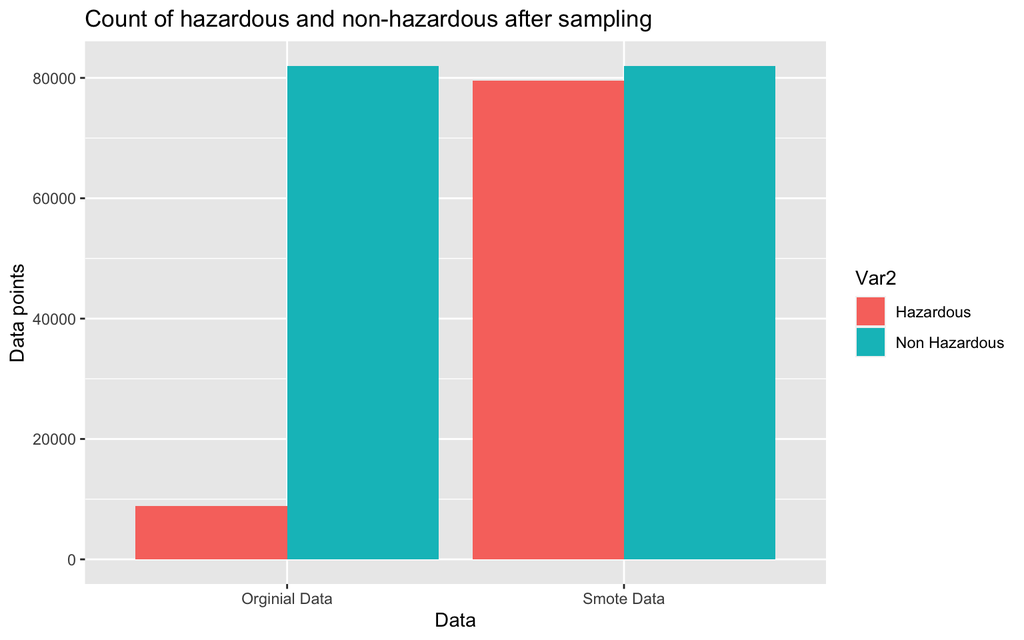

```r
tab=matrix(c(sum(neo$hazardous=="True"), sum(neo$hazardous=="False"), sum(newdata$hazardous==1), sum(newdata$hazardous==0)), ncol = 2, byrow = TRUE)
colnames(tab) <- c('Hazardous','Non Hazardous')
rownames(tab) <- c('Orginial Data','Smote Data')
tab <- as.table(tab)
my_data <- as.data.frame(tab)
ggplot(my_data,
       aes(x = Var1,
           y = Freq, fill= Var2)) +
  geom_bar(stat = "identity", position = "dodge") +
  ggtitle('Count of hazardous and non-hazardous after sampling') +
  xlab('Data') +
  ylab('Data points')
```

Before we perform modeling, we would also go over the feature selection below.

# Feature Selection

Before doing the modeling section of our analysis, we decided to conduct a feature selection. A feature selection will help us to properly identify those features, or variables, that are most important to include in our models. In this manner, we can get the best model with the given data. To do identify these features, we decided to use three relevant feature selection models, these are: Spearman Correlation Plot, Lasso Regression and Bayesian Information Criterion (BIC) plot. Each feature selection model will interpret the data in their own manner and yield a different conclusion as to which feature is best to use. Therefore, if there is a feature that is indeed important, it should, in theory, be noticeable across each of these feature selection models.

## Feature Selection: Spearman Correlation Plot

Spearman Correlation Plots identify each correlation coefficient for ranked variables. A perk of using Spearmans Correlation Plot is that we can notice which relationships might result in multicollinearity, meaning that one independent variable being highly or absolutely correlated with another independent variable. Luckily for us, we do notice some substantial multicollinearity not only with one variable but with two in our first Spearman Correlation Plot. The variables `est_diameter_min` and `est_diameter_max` are perfectly positively correlated with each other, and perfectly negatively correlated with the variable `absolute_magnitude`. So, for the previously mentioned reasons, we will re-do our Spearman Correlation Plot without both of these variables. Thus, we are left with `relative_velocity`, `miss_distance` and `absolute_magnitude` as our independent variables. As for the interpretation with our dependent variable `hazardous` this second Spearman Correlation Plot reveals to us that `absolute_magnitude` has the highest degree of influence with a ***-0.37** coefficient, then `relative_velocity` with a **0.18** coefficient, and lastly `miss_distance` with virtualy no degree of influence **0.04**.

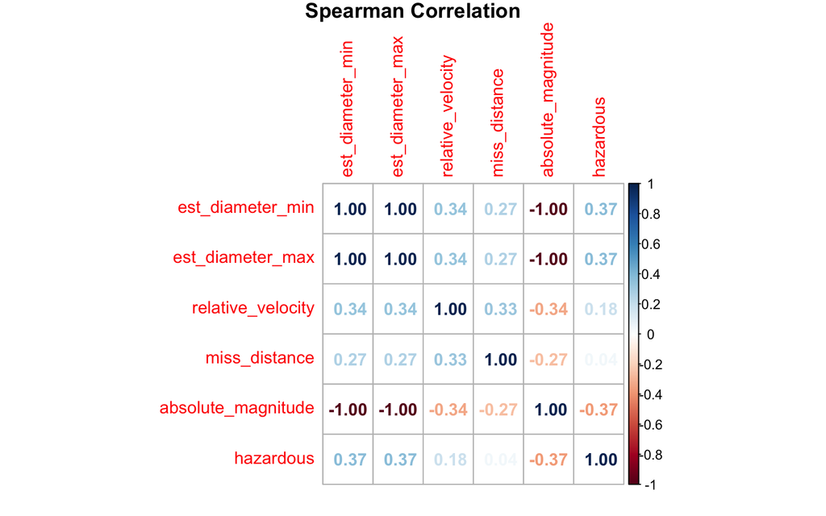

```r
library(corrplot)

neo_cor <- select(neo, c(3:6,9,10))
neo_cor$hazardous = as.numeric(as.logical(neo_cor$hazardous))

corrplot(cor(neo_cor, method ='spearman'), method = "number", title = "Spearman Correlation", outline = TRUE, mar = c(1,1,1,1))
```

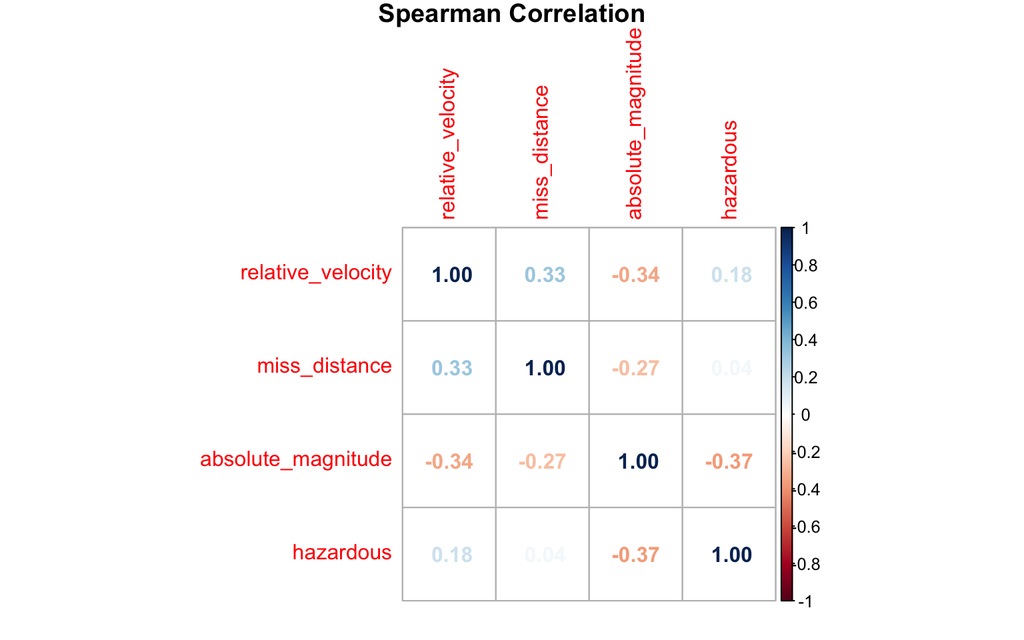

```r
neo_cor3 <- select(neo, c(5:6,9,10))
neo_cor3$hazardous = as.numeric(as.logical(neo_cor3$hazardous))

corrplot(cor(neo_cor3, method ='spearman'), method = "number", title = "Spearman Correlation", outline = TRUE, mar = c(1,1,1,1))
```

## Feature Selection: Lasso Regression

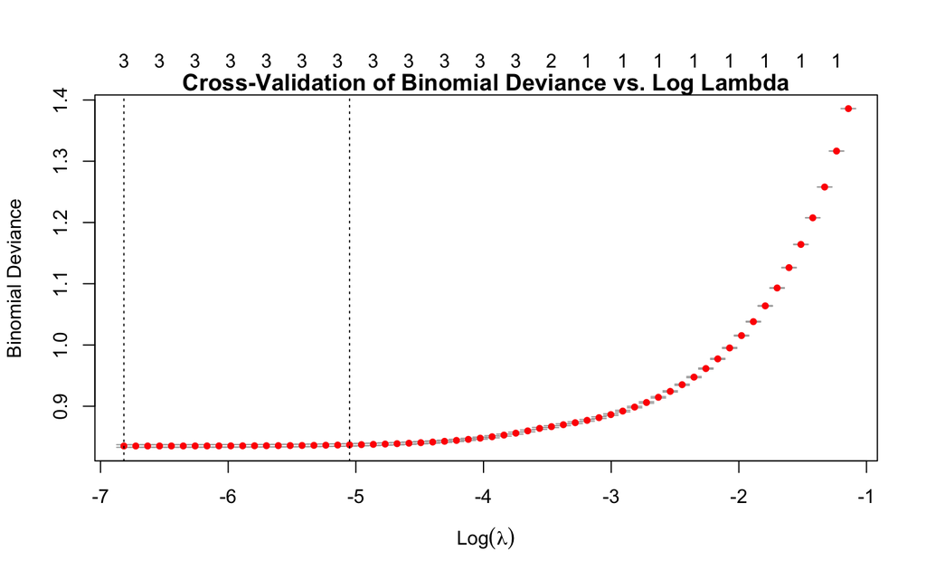

```r
library(glmnet)

newdata_lasso <- newdata

newdata_lasso$hazardous <- as.factor(newdata_lasso$hazardous)

y = newdata_lasso[,"hazardous"]

newdata_lasso_x <- scale(newdata_lasso[1:3], center = TRUE, scale = TRUE)
newdata_lasso_x <- data.frame(newdata_lasso)

x = model.matrix(hazardous ~ relative_velocity + absolute_magnitude + miss_distance, data=newdata_lasso)[,-1]

cv.lambda.lasso <- cv.glmnet(x=x, y=y, family = "binomial", alpha = 1)

plot(cv.lambda.lasso)
title(main = 'Cross-Validation of Binomial Deviance vs. Log Lambda', line = 0.2)
```

```r
cv.lambda.lasso
```

```
##
## Call:  cv.glmnet(x = x, y = y, family = "binomial", alpha = 1)
##
## Measure: Binomial Deviance
##
##      Lambda Index Measure      SE Nonzero
## min 0.00110    62   0.835 0.00216       3
## 1se 0.00641    43   0.837 0.00201       3
```

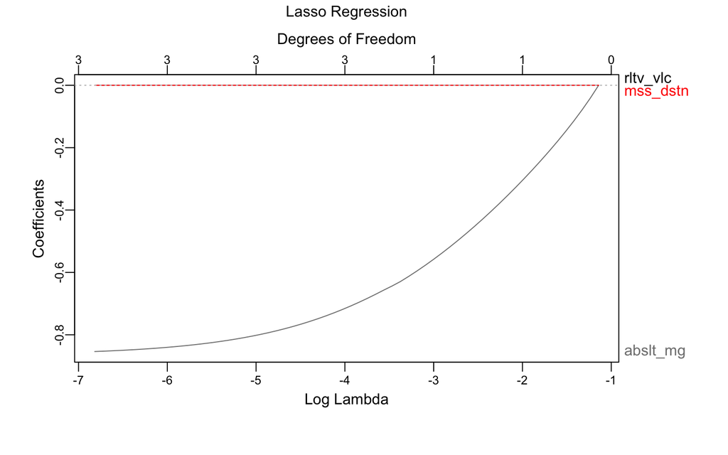

```r
library(plotmo)
plot_glmnet(cv.lambda.lasso$glmnet.fit,
     "lambda", label =TRUE, main = 'Lasso Regression')
```

## Feature Selection: Bayesian Information Criterion (BIC) plot

Last in the line-up of our feature selection models, we decided to conduct a BIC plot. A BIC plot shows us the lowest Bayesian Information Criterion point for each possible model. The logic behind the plot is that the lowest BIC possible represents the best possible the model. From our graph, we can notice that for the lowest BIC possible of **-87,000** the best model is that which includes all of the independent variables. And curiously enough, for each of the other lowest possible BIC levels, `absolute_magnitude` is included.

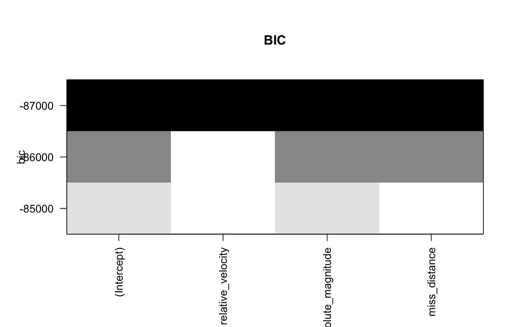

```r
newdata_glm <- newdata
newdata_glm$hazardous <- as.factor(newdata_glm$hazardous)

loadPkg("leaps")
reg.leaps <- regsubsets(hazardous~., data = newdata_glm, nbest = 1, method = "exhaustive")
plot(reg.leaps, scale = "bic", main = "BIC", las =1)
```

Thus, from our feature selections models, we have gathered that the best possible model is that which uses all of the independent variables, and that the most significant variable is `absolute_magnitude`, which recall represents the degree luminosity, calculated by its distance orbited to the sun, of the nearest earth objects.

# MODELS

The above sampling techniques were performed only with k=5. Let’s explore k value with a defined set of ranges. Ideally, k has a value between 5 and 20. We shall run a for loop to get accuracy of each odd valued k to find the optimal one.

## KNN

```r
ResultDf = data.frame( k=numeric(0), Total.Accuracy= numeric(0), row.names = NULL )
set.seed(222)
for (kval in seq(1,20,2)) {
  nasa_pred <- knn(train = nasa_train, test = nasa_test, cl=nasa_train.labels, k=kval)
  cm = confusionMatrix(nasa_pred, as.factor(nasa_test.labels) ) # from caret library
  cmaccu = cm$overall['Accuracy']
  cmt = data.frame(k=kval, Total.Accuracy = cmaccu, row.names = NULL ) # initialize a row of the metrics
  ResultDf = rbind(ResultDf, cmt)
}
xkabledply(ResultDf, "Total Accuracy Summary:")
```

Total Accuracy Summary:

| k | Total.Accuracy |
| --- | --- |
| 1 | 0.854 |
| 3 | 0.869 |
| 5 | 0.875 |
| 7 | 0.877 |
| 9 | 0.879 |
| 11 | 0.880 |
| 13 | 0.881 |
| 15 | 0.881 |
| 17 | 0.882 |
| 19 | 0.883 |

Now, with the accuracies defined for all possible k values, we shall draw a plot and see and compare the accuracies.

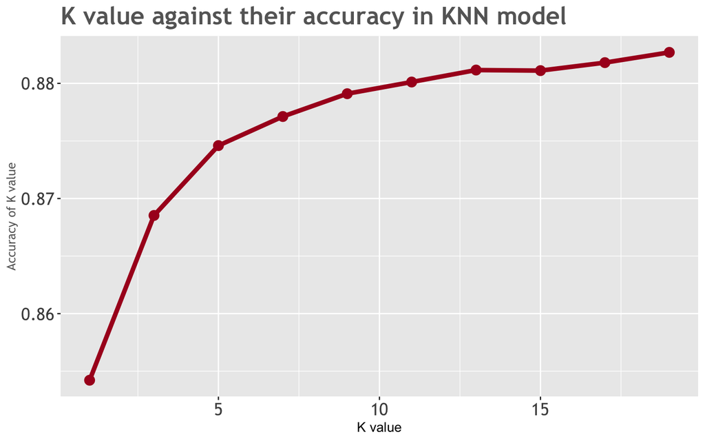

```r
ggplot(data=ResultDf, aes(x=k, y=Total.Accuracy,group=1)) +
  geom_line(color="#aa0022", size=1.75) +
  geom_point(color="#aa0022", size=3.5) +
  ggtitle("K value against their accuracy in KNN model") +
  labs(x="K value", y="Accuracy of K value") +
  theme(axis.title.y = element_text(size=10, family="Trebuchet MS", color="#666666")) +
  theme(axis.text = element_text(size=14, family="Trebuchet MS")) +
  theme(plot.title = element_text(size=20, family="Trebuchet MS", face="bold", hjust=0, color="#666666"))
```

Now, taking k=9, we shall perform model evaulation.

### KNN model Evaluation

```r
knn.9 <- knn(train=nasa_train, test=nasa_test, cl=nasa_train.labels, k=9, prob=TRUE)
print(confusionMatrix(knn.9, as.factor(nasa_test.labels), mode = "everything"))
```

```
## Confusion Matrix and Statistics
##
##           Reference
## Prediction     0     1
##          0 16376   746
##          1  4137 19130
##
##                Accuracy : 0.879
##                  95% CI : (0.876, 0.882)
##     No Information Rate : 0.508
##     P-Value [Acc > NIR] : <2e-16
##
##                   Kappa : 0.759
##
##  Mcnemar's Test P-Value : <2e-16
##
##             Sensitivity : 0.798
##             Specificity : 0.962
##          Pos Pred Value : 0.956
##          Neg Pred Value : 0.822
##               Precision : 0.956
##                  Recall : 0.798
##                      F1 : 0.870
##              Prevalence : 0.508
##          Detection Rate : 0.405
##    Detection Prevalence : 0.424
##       Balanced Accuracy : 0.880
##
##        'Positive' Class : 0
##
```

```r
library(pROC)

print(roc(nasa_test.labels, attributes(knn.9)$prob))
```

```
##
## Call:
## roc.default(response = nasa_test.labels, predictor = attributes(knn.9)$prob)
##
## Data: attributes(knn.9)$prob in 20513 controls (nasa_test.labels 0) > 19876 cases (nasa_test.labels 1).
## Area under the curve: 0.717
```

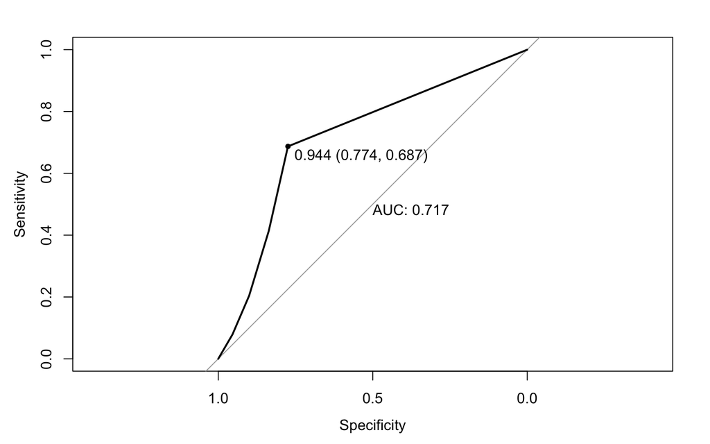

```r
plot(roc(nasa_test.labels, attributes(knn.9)$prob),
     print.thres = T,
     print.auc=T)
```

## Logistic Regression

### Interpretation of coefficients

As hinted from our feature selection, all of the independent variable’s coefficients are statistically significant. To make our interpretation of the coefficients even simpler, we decided that it would be best to describe them in terms of their odds, not log odds. Therefore, from our results we can observe that the odds of a neo being hazardous increases when its relative velocity increases, its absolute magnitude decreases and its miss distance decreases.

```r
glm.nasa <- glm(formula = hazardous ~ ., data = newdata_glm, family = binomial)

summary(glm.nasa)
```

```
##
## Call:
## glm(formula = hazardous ~ ., family = binomial, data = newdata_glm)
##
## Deviance Residuals:
##    Min      1Q  Median      3Q     Max
## -4.590  -0.493  -0.051   0.761   1.694
##
## Coefficients:
##                     Estimate Std. Error z value Pr(>|z|)
## (Intercept)         1.89e+01   1.08e-01   173.9   <2e-16 ***
## relative_velocity   8.87e-06   3.00e-07    29.6   <2e-16 ***
## absolute_magnitude -8.65e-01   4.73e-03  -182.9   <2e-16 ***
## miss_distance      -1.50e-08   3.41e-10   -44.2   <2e-16 ***
## ---
## Signif. codes:  0 '***' 0.001 '**' 0.01 '*' 0.05 '.' 0.1 ' ' 1
##
## (Dispersion parameter for binomial family taken to be 1)
##
##     Null deviance: 223927  on 161555  degrees of freedom
## Residual deviance: 134889  on 161552  degrees of freedom
## AIC: 134897
##
## Number of Fisher Scoring iterations: 6
```

### Logistic Regression: Evaluation Metrics

- Confusion Matrix: With the addition of SMOTE to our dataframe we where able to improve our confusion matrix results to yield a higher recall score. From this particular model, the accuracy turned out to be **85.30%**, specificity (FPR) **91.16%** and Recall (TPR) **80.73%**. Therefore, the model did a good job at predicting actual true hazardous neo’s, as well as an even better job at predicting actual not hazardous neo’s.
- McFadden’s value: The McFadden value, or pseudo r^2, was of **0.40**. So the model was able to interpret about 40% of the variance in the outcome of `hazardous`.
- Receiver-Operator-Characteristic (ROC) curve and Area-Under-Curve (AUC): The ROC curve appeared to be very steep indicating that it had a good True-Positive Rate (TPR) by False-Positive Rate (FPR), indicating that it performed substantially well. And lastly, the AUC was of **0.877** indicating that this was a good model to accept.

```r
set.seed(123)
#Confusion matrix
loadPkg("ModelMetrics")
xkabledply( confusionMatrix(actual= glm.nasa$y, predicted= glm.nasa$fitted.values), title = "Confusion matrix from Logit Model" )
```

Confusion matrix from Logit Model

| 1 | 2 |
| --- | --- |
| 64502 | 6251 |
| 17494 | 73309 |

```r
#McFadden's value
loadPkg("pscl")
model1r2 = pR2(glm.nasa)
```

```
## fitting null model for pseudo-r2
```

```r
model1r2
```

```
##       llh   llhNull        G2  McFadden      r2ML      r2CU
## -6.74e+04 -1.12e+05  8.90e+04  3.98e-01  4.24e-01  5.65e-01
```

```r
#Receiver-Operator-Characteristic (ROC) curve and Area-Under-Curve (AUC)
loadPkg("pROC")
prob1 = predict(glm.nasa, type ='response')
glm.nasa$prob = prob1
h1 = roc(hazardous ~ prob1, newdata_glm)
h1$auc
```

```
## Area under the curve: 0.877
```

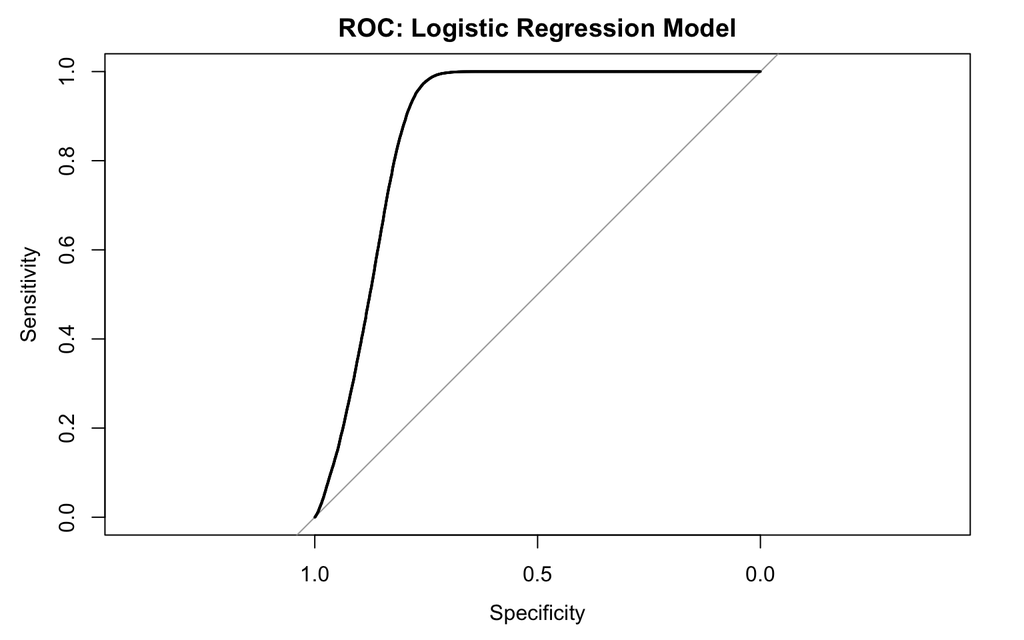

```r
plot(h1, main = 'ROC: Logistic Regression Model')
```

```r
glm.nasa$coefficients
```

```
##        (Intercept)  relative_velocity absolute_magnitude      miss_distance
##           1.89e+01           8.87e-06          -8.65e-01          -1.50e-08
```

### Logistic Regression: Visualization

From this graph we are able to identify each predicted probability, of our Logistic Regression model, by each value of `absolute_magnitude`. As observed, we notice that a good heuristic to have when it comes to hazardous or not-hazardous neo’s is whether its `absolute_magnitude` is greater or less than 22. From our model, if the `absolute_magnitude` is greater than 22 then it predicts the neo to not be hazardous, and if the `absolute_magnitude` is less than 22 it predicts the neo to be hazardous. If the neo’s `absolute_magnitude` is equal to 22 then it is a 50-50% chance of it being hazardous or not. This is a good heuristic to have in mind.

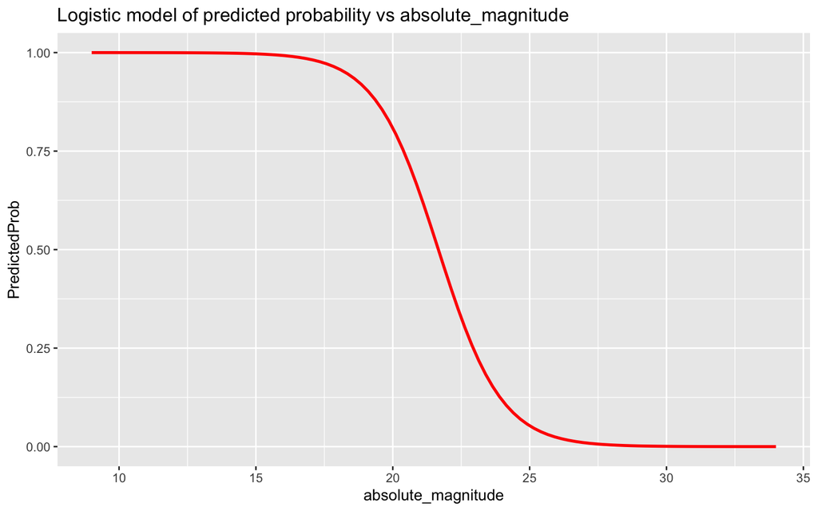

```r
glm_plot1 <- with(neo_cor3, data.frame(relative_velocity = mean(relative_velocity), miss_distance = mean(miss_distance), absolute_magnitude = rep(seq(from = 9, to = 34, length.out = 100), 2)))

glm_plot2 <- cbind(glm_plot1, predict(glm.nasa, newdata = glm_plot1, type = "link", se = TRUE))
glm_plot2 <- within(glm_plot2, {
    PredictedProb <- plogis(fit)
    LL <- plogis(fit - (1.96 * se.fit))
    UL <- plogis(fit + (1.96 * se.fit))
})

ggplot(glm_plot2, aes(x = absolute_magnitude, y = PredictedProb)) + geom_ribbon(aes(ymin = LL,
    ymax = UL), alpha = 0.2) + geom_line(size = 1, color = 'red') + labs(title = "Logistic model of predicted probability vs absolute_magnitude")
```

## Decision Trees

Decision Trees are a type of nonparametric supervised machine learning algo that work to form categorical and/or quantitative predictors. In many ways, they do exactly what they sound like: allow the reader to decide on the probability of certain outcomes based on concurrent and previous criteria.

One advantage of using trees is the ease-of-use: with minimal explanation, anyone can follow along the “branches.”

Trees are also resistant to outliers, and can be evaluated for their “data-worthiness” by industry-standard metrics of accuracy, precision, recall, and ROC/AUC.

Some disadvantages to use of trees include chance of overfitting the data and the largest trees may be unwieldy.

The following code begins by plotting a simple classification tree and showing the size of the relative “x-value” error.

```r
install.packages("rpart", repos='http://cran.us.r-project.org')
library(rpart)
```

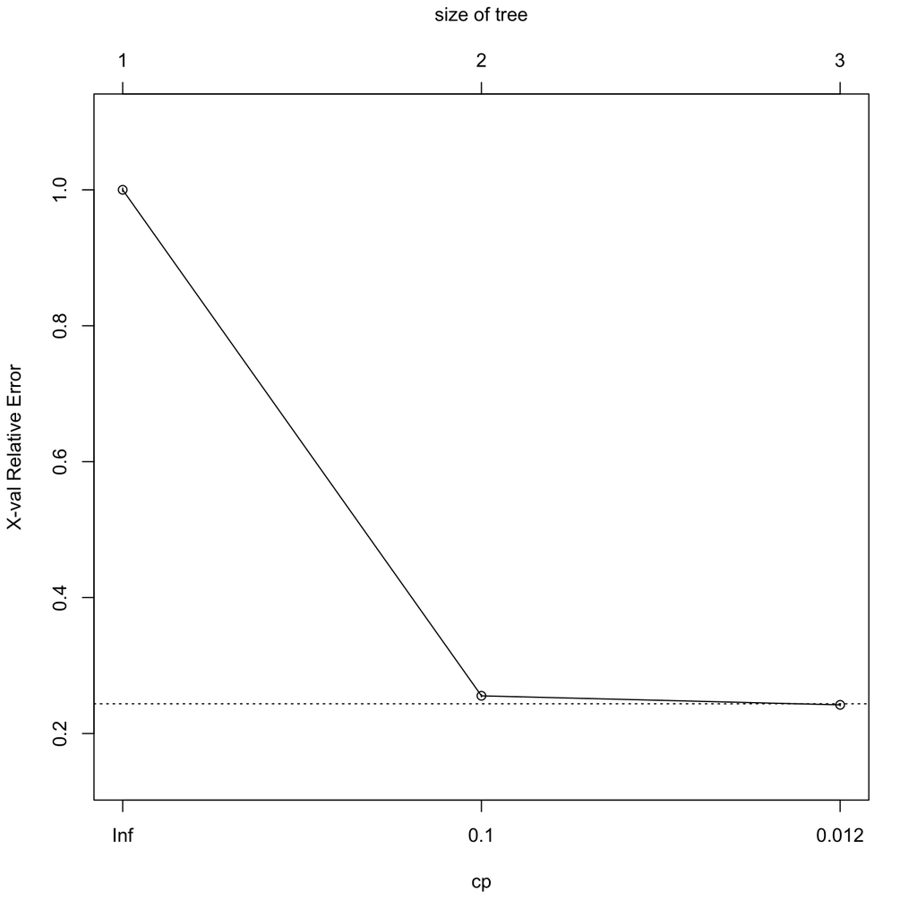

```r
set.seed(1)
newtrees = newdata
#neo <- read.csv("neo.csv")
neofit <- rpart(hazardous ~  absolute_magnitude + miss_distance + relative_velocity, data=newtrees, method="class", control = list(maxdepth = 4) )
printcp(neofit) # display the results
plotcp(neofit) # visualize cross-validation results
```

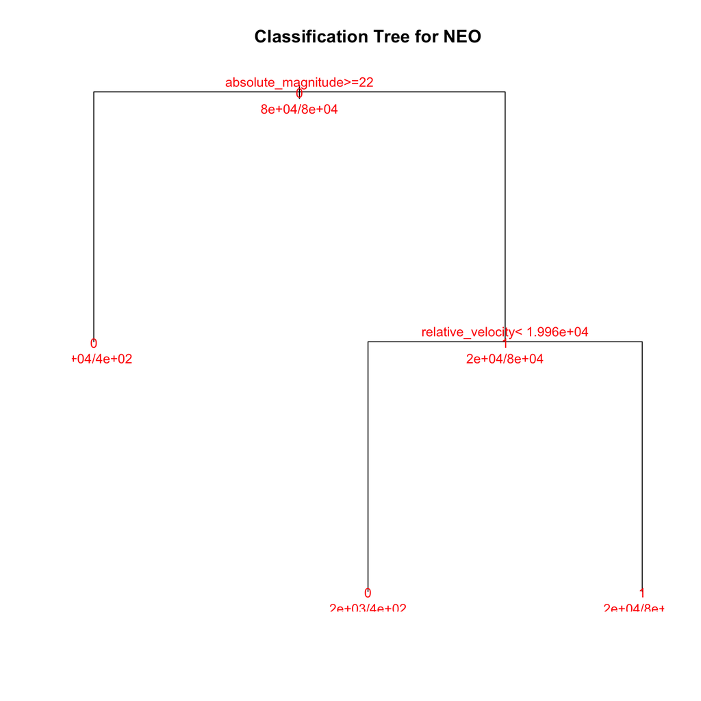

```r
summary(neofit) # detailed summary of splits

# plot tree
plot(neofit, uniform=TRUE, main="Classification Tree for NEO")
text(neofit, use.n=TRUE, all=TRUE, cex=0.9, col="red")
```

The following code allows to generate a post-script file.

```r
post(neofit, file = "neoTree.ps", title = "Classification Tree for NEO")
```

The following code to create the confusion matrix allows for detailed interpretation of accuracy, sensitivity, specificity, predicted value in either direction, and the level of precision. We are able to create a “fancy” plot using rattle.

```r
library(caret)
newdata[,'hazardous'] <- as.factor(newdata[,'hazardous'])

cm = caret::confusionMatrix( predict(neofit, type = "class"), reference = newdata[, "hazardous"] )
xkabledply(cm$table, "confusion matrix")
print('Overall: ')
cm$overall
print('Class: ')
cm$byClass
```

[output not shown]

```r
confusionMatrixResultDf = data.frame( Depth=numeric(0), Accuracy= numeric(0), Sensitivity=numeric(0), Specificity=numeric(0), Pos.Pred.Value=numeric(0), Neg.Pred.Value=numeric(0), Precision=numeric(0), Recall=numeric(0), F1=numeric(0), Prevalence=numeric(0), Detection.Rate=numeric(0), Detection.Prevalence=numeric(0), Balanced.Accuracy=numeric(0), row.names = NULL )

for (deep in 2:6) {
neofit2 <- rpart(hazardous ~  absolute_magnitude + miss_distance + relative_velocity, data=newdata, method="class", control = list(maxdepth = deep) )
cm2 = caret::confusionMatrix( predict(neofit2, type = "class"), reference = newdata[, "hazardous"] )
 cmaccu = cm2$overall['Accuracy']
 cmt = data.frame(Depth=deep, Accuracy = cmaccu, row.names = NULL )
cmt = cbind( cmt, data.frame( t(cm$byClass) ) )
 confusionMatrixResultDf = rbind(confusionMatrixResultDf, cmt)
}
```

```r
xkabledply(confusionMatrixResultDf, title="NEO Classification Trees with Varying Max Depth")
```

NEO Classification Trees with Varying Max Depth

| Depth | Accuracy | Sensitivity | Specificity | Pos.Pred.Value | Neg.Pred.Value | Precision | Recall | F1 | Prevalence | Detection.Rate | Detection.Prevalence | Balanced.Accuracy |
| --- | --- | --- | --- | --- | --- | --- | --- | --- | --- | --- | --- | --- |
| 2 | 0.881 | 0.776 | 0.989 | 0.987 | 0.811 | 0.987 | 0.776 | 0.869 | 0.507 | 0.394 | 0.399 | 0.882 |
| 3 | 0.881 | 0.776 | 0.989 | 0.987 | 0.811 | 0.987 | 0.776 | 0.869 | 0.507 | 0.394 | 0.399 | 0.882 |
| 4 | 0.881 | 0.776 | 0.989 | 0.987 | 0.811 | 0.987 | 0.776 | 0.869 | 0.507 | 0.394 | 0.399 | 0.882 |
| 5 | 0.881 | 0.776 | 0.989 | 0.987 | 0.811 | 0.987 | 0.776 | 0.869 | 0.507 | 0.394 | 0.399 | 0.882 |
| 6 | 0.881 | 0.776 | 0.989 | 0.987 | 0.811 | 0.987 | 0.776 | 0.869 | 0.507 | 0.394 | 0.399 | 0.882 |

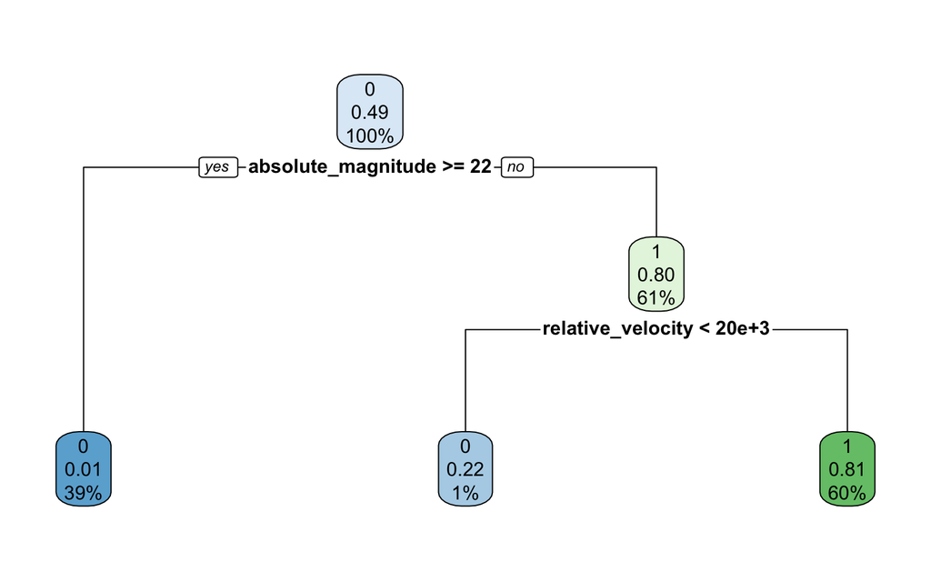

```r
#install.packages("rpart.plot", repos='http://cran.us.r-project.org')
library(rpart.plot)
#install.packages("rattle", repos='http://cran.us.r-project.org')
library(rattle)
rpart.plot(neofit)
```

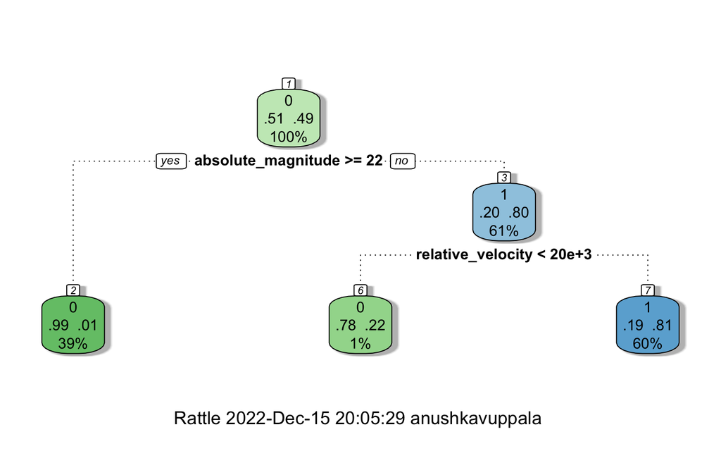

```r
fancyRpartPlot(neofit)
```

```r
install.packages("ISLR",repos='http://cran.us.r-project.org')
library(ISLR)
install.packages("tree",repos='http://cran.us.r-project.org')
library("tree")
treefit <- tree(log(miss_distance) ~ relative_velocity  + absolute_magnitude, data=newtrees)
summary(treefit)
```

[output not shown]

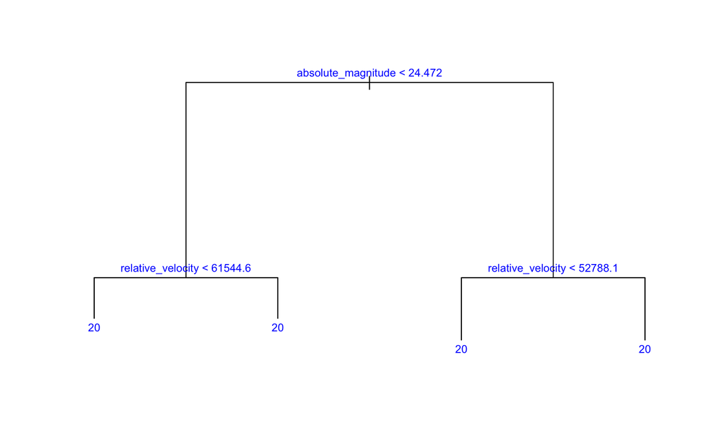

```r
plot(treefit)
text(treefit,cex=0.75, col="blue")
```

```r
install.packages("caret", repos='http://cran.us.r-project.org')
library(caret)
loadPkg("caret")
confusionMatrixResultDf = data.frame( Depth=numeric(0), Accuracy= numeric(0), Sensitivity=numeric(0), Specificity=numeric(0), Pos.Pred.Value=numeric(0), Neg.Pred.Value=numeric(0), Precision=numeric(0), Recall=numeric(0), F1=numeric(0), Prevalence=numeric(0), Detection.Rate=numeric(0), Detection.Prevalence=numeric(0), Balanced.Accuracy=numeric(0), row.names = NULL )

for (deep in 2:6) {
neofit2 <- rpart(hazardous ~  absolute_magnitude + miss_distance + relative_velocity, data=newtrees, method="class", control = list(maxdepth = deep) )
cm2 = caret::confusionMatrix( predict(neofit2, type = "class"), reference = as.factor(newtrees[, "hazardous"] ))
 cmaccu = cm2$overall['Accuracy']
 cmt = data.frame(Depth=deep, Accuracy = cmaccu, row.names = NULL )
cmt = cbind( cmt, data.frame( t(cm$byClass) ) )
 confusionMatrixResultDf = rbind(confusionMatrixResultDf, cmt)
}
```

```r
xkabledply(confusionMatrixResultDf, title="NEO Classification Trees with Varying Max Depth")
```

NEO Classification Trees with Varying Max Depth

| Depth | Accuracy | Sensitivity | Specificity | Pos.Pred.Value | Neg.Pred.Value | Precision | Recall | F1 | Prevalence | Detection.Rate | Detection.Prevalence | Balanced.Accuracy |
| --- | --- | --- | --- | --- | --- | --- | --- | --- | --- | --- | --- | --- |
| 2 | 0.881 | 0.776 | 0.989 | 0.987 | 0.811 | 0.987 | 0.776 | 0.869 | 0.507 | 0.394 | 0.399 | 0.882 |
| 3 | 0.881 | 0.776 | 0.989 | 0.987 | 0.811 | 0.987 | 0.776 | 0.869 | 0.507 | 0.394 | 0.399 | 0.882 |
| 4 | 0.881 | 0.776 | 0.989 | 0.987 | 0.811 | 0.987 | 0.776 | 0.869 | 0.507 | 0.394 | 0.399 | 0.882 |
| 5 | 0.881 | 0.776 | 0.989 | 0.987 | 0.811 | 0.987 | 0.776 | 0.869 | 0.507 | 0.394 | 0.399 | 0.882 |
| 6 | 0.881 | 0.776 | 0.989 | 0.987 | 0.811 | 0.987 | 0.776 | 0.869 | 0.507 | 0.394 | 0.399 | 0.882 |

## AUC for Decision

```r
library(ROCR)
tree.preds <- predict(neofit2, as.data.frame(nasa_test),type = "prob")[,2]
library(pROC)
tree.roc <- roc(nasa_test.labels, tree.preds)
print(tree.roc)
```

```
##
## Call:
## roc.default(response = nasa_test.labels, predictor = tree.preds)
##
## Data: tree.preds in 20513 controls (nasa_test.labels 0) < 19876 cases (nasa_test.labels 1).
## Area under the curve: 0.5
```

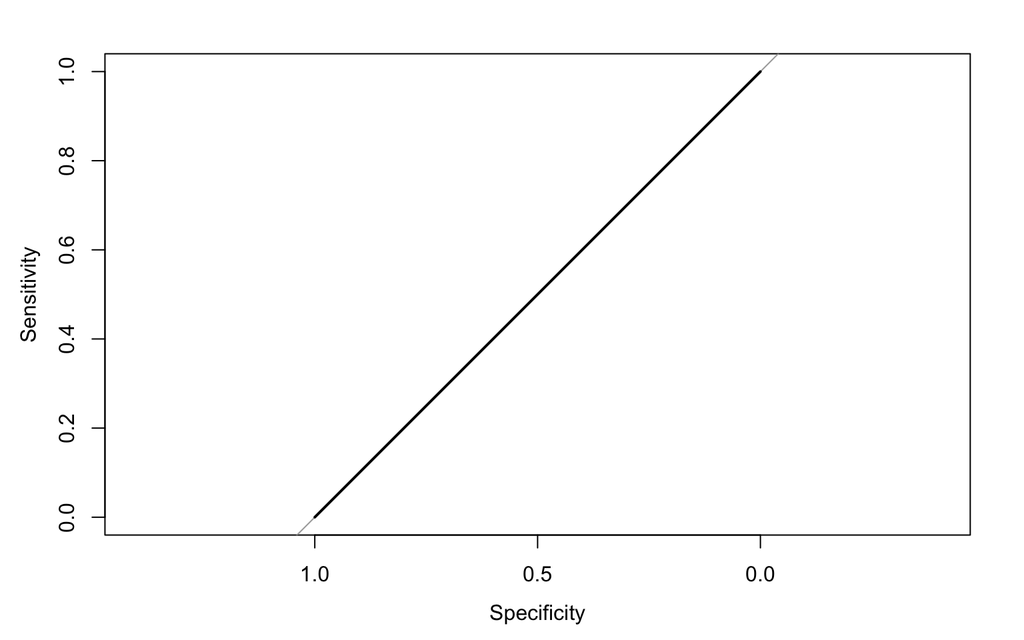

```r
plot(tree.roc)
```

# Model Comparisons

Now, let’s compare the above 3 models.

```r
scores <- data.frame ( model = c ("KNN","Logisitic Regression","Classification Tree"),
  Accuracy  = c("87.9%", "85.3%", "88.1%"),
                  Specificity = c("96.2%", "91.16", "98.9%"),
                    Recall = c("79.8%", "80.73%", "77.6%"),
                    AUC = c("0.717", "0.877", "0.51"))

xkabledply(scores)
```

Model: model ~ Accuracy + Specificity + Recall + AUC

[output not shown]

## Sample Predictions

```r
sampleprediction1 = data.frame(relative_velocity = 17.38, absolute_magnitude = 17.1, miss_distance = 1.2417e+8)

sampleprediction2 = data.frame(relative_velocity = 21.80, absolute_magnitude = 18.02, miss_distance = 2.543e+8)

predict(glm.nasa, newdata = sampleprediction1, type = 'response')
```

```
##     1
## 0.901
```

```r
predict(glm.nasa, newdata = sampleprediction2, type = 'response')
```

```
##     1
## 0.368
```

# Limitations

The `neo.csv` data set posed limitations in the variables, description and dictionary. Since the dataset was obtained from a web-based environment, kaggle, we had insufficient variables, a poor description of the dataset and no data dictionary provided. In terms of the variables provided, it would have been ideal to have one regarding the trajectory towards, or away, from earth, as well as other potentially hazardous, or not hazardous, variables. Nevertheless, we were restricted to just using the three variables that were quantifiable in order to characterize the potential of it being hazardous. In retrospect, just using these three variables might have been an over-simplification in our determination of a hazard. On the other hand, the description of the dataset is very limited given the constraint of using Kaggle. It would have been better if the dataset was obtained straight from a NASA website or API, however this was not possible. It would have been a huge perk to know how these variables are being used by NASA professionals, what characterizes an instance to be recorded multiple times, and why they initially attributed the boolean value for Hazardous. Finally, when it came to providing a data dictionary, the kaggle website did not have one. Thus, we had to do our own research as to what these variables meant, and what they were describing. Therefore, with insufficient variables, a poor description and no data dictionary it was difficult to infer, or fully understand, the root of a hazardous or not hazardous asteroid to fully answer our question.

# References:

- Kaggle Dataset (Kaggle): Vani, S. (2022, June 17). NASA - Nearest Earth objects. Kaggle. Retrieved November 2, 2022, from https://www.kaggle.com/datasets/sameepvani/nasa-nearest-earth-objects
- Center for Near Earth Objects Studies (CNEOS): NASA. (n.d.). Neo basics. NASA. Retrieved November 2, 2022, from https://cneos.jpl.nasa.gov/about/neo_groups.html
- NASA (NASA): Bardan, R. (2022, October 11). NASA confirms Dart Mission Impact Changed Asteroid’s motion in space. NASA. Retrieved November 2, 2022, from https://www.nasa.gov/press-release/nasa-confirms-dart-mission-impact-changed-asteroid-s-motion-in-space
- Araujo, R. A. N., & Winter, O. C. (2014). Near-Earth asteroid binaries in close encounters with the Earth. Astronomy & Astrophysics, 566, A23.
- Peter O. K. Krehl (2008). History of Shock Waves, Explosions and Impact: A Chronological and Biographical Reference. Springer Science & Business Media. p. 404. ISBN 978-3-540-30421-0.
- Tonry, J. L. (2010). An early warning system for asteroid impact. Publications of the Astronomical Society of the Pacific, 123(899), 58.